# Ribosomal Protein L18

Vladislav Mozgovoy

12/17/2020

### Цели :

Все последующие действия требуется выполить для **ribosomal protein L18**

##### Задание 1:

1. Измерить длину 3 водородных связей
2. Между какими атомами есть связи
3. Есть ли странные находки
4. Каковы их длины
5. Есть ли отличие от табличных значений

##### Задание 2:

1. Найти второй ортолог
2. Построить структурное выравнивание
3. Найти значение RMSD
4. Раскрасить мисмэтчи и индели

### Обработка:

#### Задание 1:

Рассмотрим **ribosomal protein L18**, в [RCSB PDB](https://www.rcsb.org/), у него есть 2 ортолога 1OVY и 1ILY  
Для 1 задания выберем **1OVY**  
Чтобы загрузить белок необходимо выполнить

```
fetch 1OVY
```

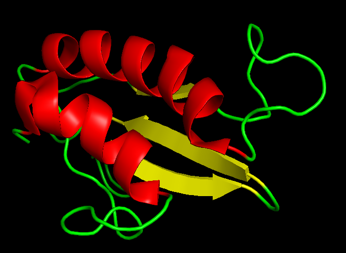

Выберем альфа спираль

```
select helix, (ss h)
create ahelix, (helix)
```

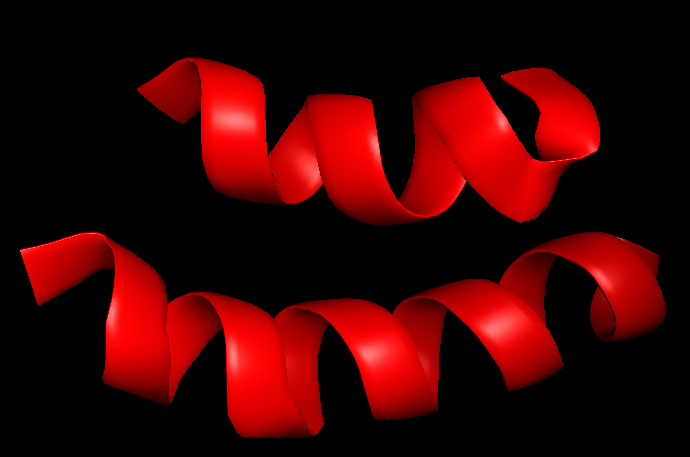

Отобразим водородные связи.  
Для этого выберем пункт в меню **[A] -> find -> polar contacts -> excluding solvent**

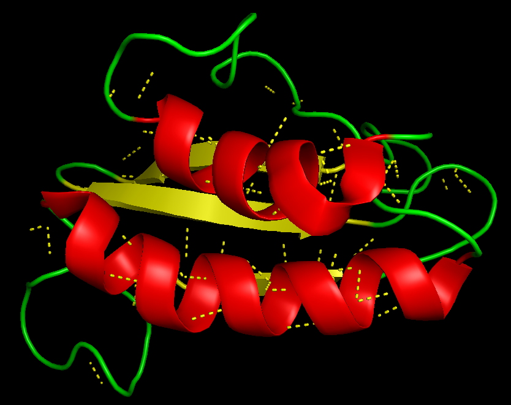

Отобразим длины водородных связей  
Для этого выберем водородные связи и нажмем **[S] -> show -> labels**  
Также отобразим спирали в ином виде **[S] -> show as -> sticks**, чтобы было ясно, что с чем соединяют водородные связи.

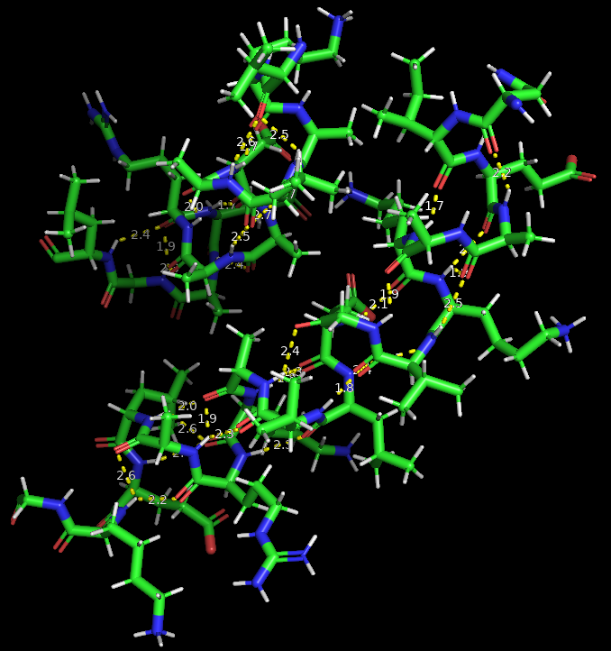

```
get_distance /ahelix/A/A/ARG`84/O, /ahelix/A/A/LYS`88/H
get_distance /ahelix/A/A/ARG`84/H, /ahelix/A/A/LEU`80/O
get_distance /ahelix/A/A/ALA`85/C, /ahelix/A/A/GLU`87/C
```

[figure not shown]

[figure not shown]

[figure not shown]

##### Ответы на вопросы:

```
run get_raw_distances
get_mean_distance ahelix_polar_cont
```

[figure not shown]

#### Задание 2:

1. Возьмем для этого задания 1ILY
2. Вполним команду **Plugin -> Alignment**

```
align 1ILY, 1OVY, object=alnobj
```

3. RMSD = 3.433
4. Раскрасим мисмэтчи красным (части 1ILY) и желтым (части 1OVY) и индели фиолетовым

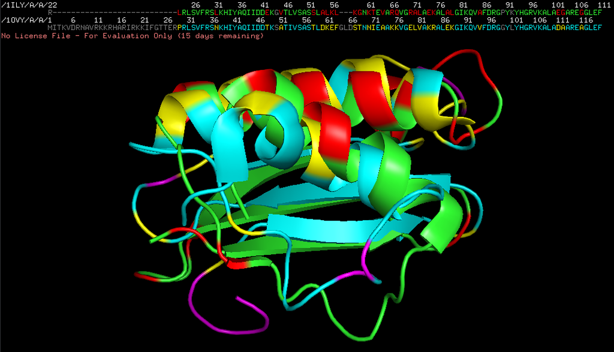